# Using faecal metabarcoding to examine consumption of crop pests and beneficial arthropods in communities of generalist avian insectivores - Garfinkel - 2022 - Ibis - Wiley Online Library

Czechs- Biological Institution

[Ibis](https://onlinelibrary.wiley.com/journal/1474919x)

[Volume 164, Issue 1](https://onlinelibrary.wiley.com/toc/1474919x/2022/164/1) p. 27-43

[figure not shown]

Original Paper

Full Access

# Using faecal metabarcoding to examine consumption of crop pests and beneficial arthropods in communities of generalist avian insectivores

[Megan Garfinkel](https://onlinelibrary.wiley.com/action/doSearch?ContribAuthorRaw=Garfinkel%2C+Megan),

[Emily Minor](https://onlinelibrary.wiley.com/action/doSearch?ContribAuthorRaw=Minor%2C+Emily),

[Christopher J. Whelan](https://onlinelibrary.wiley.com/action/doSearch?ContribAuthorRaw=Whelan%2C+Christopher+J),

First published: 28 June 2021

https://doi.org/10.1111/ibi.12994

Citations: 2

Associate Editor: Frank Rheindt

## Abstract

Generalist insectivorous birds can provide ecosystem services in agricultural landscapes by consuming arthropod pests, or they can provide disservices when they consume beneficial arthropods. To examine bird impacts on arthropod communities, including pest control services, we need to know which arthropods birds commonly consume. Faecal metabarcoding is an emerging technique that can be used to identify prey from faecal samples, often to the species level. We used faecal metabarcoding to study diets of birds inhabiting the ecotone between soybean fields and adjacent grasslands in a largely agricultural landscape in Illinois, USA, during the summer of 2017. Whereas previous studies have used faecal metabarcoding to compare bird diets among species or among capture sites, we analysed samples from multiple species within a community at replicate sites. We collected and sequenced DNA from 132 faecal samples from 25 bird species captured at six sites. We found that birds consumed an extremely large and varied diet that differed among both species and sites, suggesting that birds were consuming prey opportunistically as available at each site. Of the nine most commonly detected prey species, three are known pests of soybeans. Bird diets also contained significantly more species of herbivorous prey than natural enemies. Finally, we discovered that American Goldfinches *Spinus tristis*, a highly granivorous species, may consume arthropods more frequently than expected and thus may provide ecosystem services in agricultural landscapes. Our study demonstrates that birds within this system consume a large variety of prey, suggesting that they may be able to respond quickly to pest outbreaks and contribute to agricultural resiliency.

Generalist insectivorous birds often have a wide variety of prey items to choose from, particularly during the breeding season (Wiens & Rotenberry 1979, Siemann *et al*. 1999). Studying bird diets informs our understanding of the ways that birds select or compete for food (Kaspari & Joern 1993, Sherry *et al*. 2016), the top-down trophic pressures exerted by birds on prey (Mäntylä *et al*. 2011) and the ways that these actions interact in the human dimension to provide biological control services (Crisol-Martínez *et al*. 2016). Generalist insectivorous birds often provide valuable ecosystem services by consuming arthropod pests (Sekercioglu *et al*. 2016). However, a growing body of literature suggests that these same birds can also provide indirect ecosystem disservices when they consume ‘beneficial’ prey such as arthropod natural enemies that would otherwise control pests (Martin *et al*. 2013, 2015, Garfinkel *et al*. 2020). The most direct way to predict whether a bird will provide services or disservices is by determining which arthropod species that bird consumes. Explicating species- and site-specific diet differences highlights the factors that shift the balance of avian function between provision of net services and disservices.

Ornithologists have historically studied bird diets using a variety of destructive or invasive methods. Most early studies relied on dissection of the stomachs of collected bird specimens (e.g. McAtee 1912). Other methods include the use of emetics to force regurgitation of stomach contents (Poulin & McNeil 1994, Diamond *et al*. 2007) and application of ligatures to nestlings to prevent food from being swallowed (Rosenberg & Cooper 1990). These methods vary in their ability to distinguish arthropod species from each other, they are labour-intensive (Pompanon *et al*. 2012) and prey items retrieved from stomachs are often too degraded to identify to the species level (Sherry *et al*. 2016). More recently, ecologists have employed high-throughput DNA sequencing technology to identify species via ‘faecal metabarcoding’ (Valentini *et al*. 2009, Pompanon *et al*. 2012). Specifically, faecal samples are collected directly from birds, often during standard ringing operations, and DNA is then extracted from the faecal sample. This resulting sample is a mixture of host, prey and microbial DNA (Deagle *et al*. 2005). Although DNA in faecal samples is degraded by digestion, use of specialized primers to amplify minibarcodes allows detection of prey DNA, which can often be identified to the species level (Valentini *et al*. 2009). This is especially useful when dealing with arthropods that can be identified to the species level visually only by examining small structures such as genitalia (Triplehorn & Johnson 2005). Faecal metabarcoding, therefore, provides data with a higher degree of specificity in a less invasive way compared with traditional diet study methods (Pompanon *et al*. 2012). This makes it an ideal technique for examining potential pest control services and disservices by birds in agro-ecosystems (King *et al*. 2015) because species-level data are critical to assess whether birds actually consume important crop pest species.

Although it is important to know about the diet of individual bird species, the entire bird community within a system may potentially contribute to net positive or negative effects on insect populations. Many previous studies have used faecal metabarcoding techniques to examine the diet of a single bird species (e.g. Jedlicka *et al*. 2017, McInnes *et al*. 2017, Sullins *et al*. 2018, McClenaghan *et al*. 2019). Some of these studies also compare diets within a single species among capture sites (e.g. Shutt *et al*. 2020). However, fewer have used faecal metabarcoding to examine bird diets at the wider community level (but see Crisol-Martínez *et al*. 2016) and we know of no other studies that have compared the diets of birds in communities across replicate sites. The advantage of comparing the diets of bird species within a community is that this provides information about how different species contribute to net effects on the arthropod community (Maas *et al*. 2015). These community-wide data may also enable us to understand how community members interact or compete with each other (Sherry *et al*. 2020).

In the Midwest region of the USA, many large-scale conventional agricultural fields are interspersed with small grasslands and prairies. Grasslands provide habitat for many bird species, and those birds forage for arthropods in the surrounding agricultural fields (Garfinkel *et al*. 2020). Soybeans *Glycine max* are one of the dominant crops in this region, and they are vulnerable to a variety of arthropod pest species (Hartman *et al*. 2015); the potential loss of soybean crop yield from arthropod pests is estimated to be approximately 11% (ranging from 4% to 16%) worldwide (Oerke 2006). Crop loss due to pests is expected to increase under a changing climate, with pest outbreaks potentially becoming more common (Walthall *et al*. 2012). With these expected increasing pressures, the ability to respond quickly to pest outbreaks will be important for ensuring farmland resiliency. Specialist natural enemies, such as many parasitoids and other arthropod predators, require a constant food source even during times of low pest density to sustain their populations (Dosskey *et al*. 2017). Generalist insectivorous birds, on the other hand, are more adaptable to changing prey densities because they are highly mobile (Barber *et al*. 2008) and large enough to consume a wide variety of pest species. This implies that birds have the potential to control insect populations beyond what is already accomplished by arthropod natural enemies (Garfinkel *et al*. 2020).

In this study, we used faecal metabarcoding to examine the diets of communities of birds in replicate sites within a mixed grassland–agricultural landscape in the Midwestern USA. Specifically, we studied the diets of birds captured at the ecotone between soybean fields and grasslands, which may forage in both habitats. The goals of our study were to determine which arthropod species were consumed by birds within this mixed soybean/grassland system and to examine differences in diet among bird species and sites. In particular, we hypothesized that birds would consume known soybean pest species, and tested whether birds consumed more arthropod herbivores than natural enemies. By comparing bird communities in multiple locations, we can gain insight into how diets vary across the landscape, as well as provide valuable information on the diets of grassland bird communities in an economically important study system.

## METHODS

### Study sites

We collected faecal samples from birds for a faecal metabarcoding diet analysis at six sites in Kane, DeKalb and Ogle Counties in northern Illinois, USA (Fig. 1). Because we were interested in the diets of birds that live and forage near both agricultural and grassland habitats, we selected sites that had a soybean field that shared at least one field edge with a grassland. These grasslands were all owned by either county forest preserve districts or The Nature Conservancy and were managed in various ways to prevent forest encroachment and maintain native plant diversity (i.e. burning, mowing and targeted control of invasive plant species). We only used sites where we were able to obtain permission from all involved public and private landowners (of both agricultural and grassland parcels) to conduct our research. Each capture site was separated from others by at least 1 km. The mean size of the soybean fields was approximately 34 ha, and the mean size of grasslands was approximately 110 ha (see Appendix Table A1 for site identification, ownership and measurements). Multiple bird species were detected at all six of the study sites. The bird communities across all sites were similar, but not identical, as determined by point counts conducted for a related study (unpubl. data).

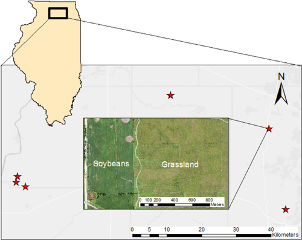

**Figure 1**

Open in figure viewer[PowerPoint](https://onlinelibrary.wiley.com/action/downloadFigures?id=ibi12994-fig-0001&doi=10.1111%2Fibi.12994)

Six sites where birds were captured for faecal sample collection in northern Illinois, USA. Sites are represented by stars, and all are separated from each other by at least 1 km. All sites included a grassland directly adjacent to a soybean field, although the extent of grassland and cropland differed among sites. In the enlarged example study site pictured, the wavy light line is a crushed limestone walking trail. [Colour figure can be viewed at [wileyonlinelibrary.com](http://wileyonlinelibrary.com/)]

### Faecal sample collection

We operated mist-nets twice at each of our study sites in 2017, once from 1 to 11 June, and once from 29 June to 20 July. During each mist-netting session, we set up nets at dawn and operated them either until noon or until conditions became too hot and/or windy to continue. To capture birds that probably foraged in both habitat types, we placed the mist-nets opportunistically between the soybean field and grassland, or within approximately 20 m of that edge within either habitat (except in one soybean field, where we were able to place some nets approximately 50 m into the field interior). Because we could not remove or trim plants in the cropland or prairie, we placed the nets wherever the habitat provided a natural net lane where the net would not become entangled in vegetation. We operated between seven and 10 mist-nets (some 12 m and others 9 m in length) simultaneously during each ringing session, with the goal of capturing as many birds as possible. Because the number of net hours at each site differed, we have not drawn conclusions about bird abundance from our capture data.

We placed each bird extracted from the mist-nets into a new paper bag for no more than 30 min (generally much less time) until it defecated. For many birds, we were able to tell if defecation had occurred because a small wet spot would be visible on the outside of the paper bag; this allowed us to process birds as quickly as possible without constantly checking inside the bag. For larger birds (or species that tended to have wet faeces, e.g. due to fruit consumption), we further placed the paper bag inside a fabric bird bag to avoid accidental release if the wet area of the paper bag tore. We were unable to obtain a faecal sample from eight individual birds for various reasons, including accidental release before a sample was obtained or the bird did not defecate within approximately 30 min.

We used disposable gloves and spatulas, which were changed between birds, to avoid cross-contamination while collecting the faecal samples from the paper bags. We transferred each faecal sample to a labelled 2-mL tube with 90% ethyl alcohol and placed it on ice in an insulated cooler. We then ringed the bird, collected standard measurements and demographic data, and released it. Once out of the field for the day, we stored the faecal samples at –20 °C. At the end of the field season, all samples were transferred to storage at –80 °C.

### DNA extraction and sequencing

We extracted DNA from faecal samples using PowerSoil DNA Isolation Kits (Qiagen). During the bead-beating step of extraction, we homogenized our samples using a FastPrep-24 5G Homogenizer (MP Biomedicals). Library preparation, pooling and sequencing were performed at the University of Illinois at Chicago Genome Research Core within the Research Resources Center. Genomic DNA was amplified by polymerase chain reaction (PCR) with primers LCO1490F/COI-CFMRa (adapted from Jusino *et al*. 2019), which targets the *COI* gene of insectivorous animals. We selected these primers because they have been shown to amplify a higher percentage of arthropod taxa from faecal samples than other commonly used barcoding primer pairs (Jusino *et al*. 2019). Amplicons were generated using a two-stage ‘targeted amplicon sequencing’ protocol as described in Naqib *et al*. (2018). The primers contained 5' common sequence tags (common sequences 1 and 2, or CS1 and CS2, e.g. Moonsamy *et al*. 2013). Detailed PCR and sequencing methods are described in Appendix A.

### Bioinformatics and diet analysis

We analysed sequence data using an open-source bioinformatics pipeline, AMPTk, that has been optimized for handling amplicons of varying lengths and which employs a variety of sequence quality filtration steps (Palmer *et al*. 2018). In short, AMPTk pre-processes the data by merging paired-end reads via USEARCH, and removes primers and trims sequences. It then clusters data into operational taxonomic units (OTUs) by employing a DADA2 de-noising algorithm followed by 97% clustering using VSEARCH. The sequences are then filtered to remove ‘index-bleed’ between samples. Finally, OTUs are assigned taxonomy using a hybrid taxonomy assignment method based on global alignment, UTAX and SINTAX (https://amptk.readthedocs.io/en/latest/taxonomy.html), which makes use of the BOLDv4 database (Ratnasingham & Hebert 2007, Palmer *et al*. 2018).

Sequence read counts cannot be reliably used to infer the proportion of diet contributed by each OTU due to PCR biases (Yu *et al*. 2012, Jedlicka *et al*. 2017). We therefore transformed the OTU sequence read counts to OTU presence or absence for each sample. Presence/absence data may introduce biases by excluding poorly amplified diet items (Deagle *et al*. 2019). We attempted to include as many OTUs as possible, including those with low read counts, while still excluding artefacts by employing both read thresholds and read normalization. A limitation of this approach, however, is that some prey species might have been omitted from analysis.

We first considered all OTUs with fewer than 10 reads per sample to be absent, and removed them from further analysis. We then normalized the remaining sequence reads based on the total arthropod read counts per sample, and considered only OTUs with at least 1% of the reads to be present (see Deagle *et al*. 2019 for a discussion of various methods to determine diet components from faecal metabarcoding). The 1% threshold is commonly used because it significantly reduces the percentage of contaminated samples (Ando *et al*. 2018, 2020). However, because we had some samples with relatively few overall arthropod reads, we added the minimum 10-read threshold to exclude OTUs that comprised a large percentage of the total reads, but still had only very few reads. We selected the 10-read threshold after pre-processing and examining our data, and also based on its use in several previous studies (e.g. McClenaghan *et al*. 2019, Moran *et al*. 2019, Ando *et al*. 2020, Kaunisto *et al*. 2020). Together, these steps allowed us to exclude low read-count OTUs that were probably artefacts. We used this transformed presence–absence dataset for all further statistical tests and diet summaries.

Our four PCR-negative controls showed a low level of contamination, which is fairly standard in this type of study (McKnight *et al*. 2019). Our negative controls contained a mean of 1355 OTU reads (range = 1199–1713 total reads). None of the contaminant OTUs was present in more than one negative control. Of the 10 OTUs detected in our negative controls, four were in the phylum Chordata and therefore already excluded from our analyses. Of the remaining six potential contaminant arthropod sequences, only three were present in samples with read abundances above our presence threshold. We removed two of these potential contaminant OTUs from our dataset but left the third because it was present in much higher abundances in a sample than in the negative control (*sensu* Kaunisto *et al*. 2020).

### Arthropod feeding guild determinations

We assigned a feeding guild to each OTU that was identified to the species level in Arthropoda. We used Triplehorn and Johnson (2005) and Parr *et al*. (2014) to assign guilds. We grouped arthropods into three broad guilds: natural enemy, herbivore and ‘other’. Natural enemies included predatory arthropods and parasitoids. Herbivores included arthropods that feed on living plant material in a way that can damage a plant (i.e. arthropods that consume pollen or nectar were not included in this category). The ‘other’ category included all species that do not fit into either of the previous categories, including detritivores and generalist omnivores. Arthropods that consume different food types at different life stages were placed into the ‘other’ category only if they would be considered herbivores during one stage and natural enemies during another. Those that would be grouped as natural enemy or herbivore during one life stage and ‘other’ for a different life stage were grouped with either natural enemies or herbivores as appropriate.

### Diet summaries and statistical analyses of between-group differences in diet

Since our sample sizes were relatively small and unevenly distributed among species, site, sex, capture date, etc., we did not feel it was appropriate to build a single model accounting for all of these variables simultaneously. Instead, for the analyses below, we examined three subsets of our bird community: (1) the entire bird community: data from all bird species sampled, (2) the common species subset: data only from bird species represented by at least five faecal samples, and (3) data only from the Song Sparrow *Melospiza melodia*, the bird species from which we collected the greatest number of faecal samples (Fig. 2). Because we had an unbalanced design with varying numbers of faecal samples from each species and site (Appendix Table A2), we used only summary statistics to describe the diets of the entire bird community. To test statistically for dietary differences between species and sites, we used the common species subset data to ensure that all included bird species had sufficient replication (note that Crisol-Martínez *et al*. 2016 included bird species represented by at least four faecal samples in a similar analysis). We chose species with a minimum of five faecal samples for the common species subset because there was a natural break in the distribution of samples at that point (Fig. 2). Finally, we used the Song Sparrow subset to compare diets among sites within a single species. Because we were addressing different questions with each data subset, we applied different statistical tests to each subset as described below.

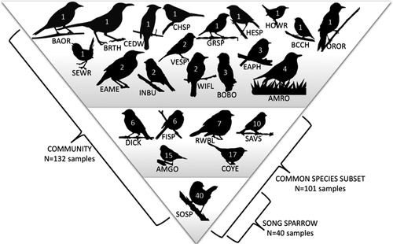

**Figure 2**

Open in figure viewer[PowerPoint](https://onlinelibrary.wiley.com/action/downloadFigures?id=ibi12994-fig-0002&doi=10.1111%2Fibi.12994)

Bird species included in DNA diet analysis. White numbers represent the number of faecal samples collected from each bird species. Bird species is indicated by the standardized four-letter alpha code below each image, which are listed in Appendix Table A2. Diet data were summarized at three levels (community, common species subset and the most frequently sampled species).

For the common species subset, we calculated the proportion of a faecal sample composed of herbivorous species by dividing the number of herbivore species per sample by the total arthropod species richness per sample. We also calculated the proportion of a faecal sample composed of natural enemies in the same way. Although these values do not explain differences in total consumption of different insects (i.e. neither prey biomass nor abundance can be inferred), they do describe the diversity of species that have been consumed. We used non-parametric Kruskal–Wallis rank sum tests to determine whether the proportion of herbivores within a bird’s diet differed by bird species or capture site. When Kruskal–Wallis tests indicated a significant difference between groups, we used Dunn’s *post-hoc* test with Bonferroni adjustment to examine the between-group differences further (Dunn 1964, Dinno 2017). We also used paired Wilcoxon signed rank tests to determine whether faecal samples contained proportionally more herbivore species than natural enemies.

For both the common species subset and the Song Sparrow data subsets, we used Sorenson distance matrices to describe the arthropod community composition found among faecal samples. These distance matrices included all arthropod OTUs after filtering as described above, including OTUs that were not identified to the species level. We used permutational multivariate analysis of variance (PERMANOVA) tests on the distance matrices to determine whether there were significant differences in diet composition among bird species and among birds captured at different sites (for the Song Sparrow data subset, we only compared sites; Anderson 2017). Specifically, PERMANOVA tests the null hypothesis that the centroids of different groups in multivariate space are equivalent (Anderson & Walsh 2013). Therefore, a significant PERMANOVA test can be due either to differences in centroid location among groups or to heterogeneity in dispersion within groups, or to both. Consequently, when we found significant PERMANOVA test results, we followed up with a PERMDISP test, which specifically tests for heterogeneity of within-group dispersion. In other words, a significant PERMANOVA test would indicate that diets differ among groups; a significant PERMDISP test would indicate that this was at least partly due to within-group dispersion of diets differing among groups. Both the PERMANOVA (with 9999 permutations) and the PERMDISP analyses were conducted using the R package *Vegan* (Oksanen *et al*. 2019).

We used principal coordinates analysis (PCoA) plots to visualize differences in diet composition among species and among sites within the common species subset data (Paliy & Shankar 2016). Within PCoA plots, we drew ellipses around groups based on the assumption of a multivariate t-distribution (Wickham 2016).

## RESULTS

### Community summary

At the entire community level, four arthropod orders were detected in at least 50% of faecal samples: Diptera, Hymenoptera, Coleoptera and Lepidoptera (Fig. 3). Nine arthropod species were detected in at least 10 faecal samples each (Fig. 4). Of these most commonly detected arthropod species, three are known to be potential pests of soybeans: Imported Long-horned Weevil *Calomycterus setarius* (Rice & Pilcher 1997); Japanese Beetle *Popillia japonica* (Shanovich *et al*. 2019) and Black Cutworm *Agrotis ipsilon* (Ogles *et al*. 2016). The most frequently detected species of all arthropod species was *Calomycterus setarius*, which was present in 41.6% of faecal samples (Fig. 4). The Japanese Beetle was detected in diets of 13 bird species and in birds sampled at all of the sites, with a range of 1–8 detections per site.

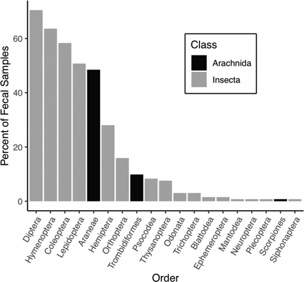

**Figure 3**

Open in figure viewer[PowerPoint](https://onlinelibrary.wiley.com/action/downloadFigures?id=ibi12994-fig-0003&doi=10.1111%2Fibi.12994)

Percentage of faecal samples containing DNA from arthropod orders in the classes Arachnida and Insecta. *n* = 132 faecal samples from 25 bird species.

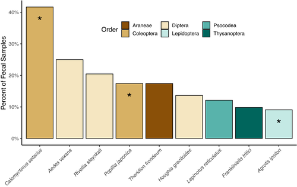

**Figure 4**

Open in figure viewer[PowerPoint](https://onlinelibrary.wiley.com/action/downloadFigures?id=ibi12994-fig-0004&doi=10.1111%2Fibi.12994)

Percentage of faecal samples containing DNA from the most commonly detected arthropod species (i.e. detected in at least 10 faecal samples). Bars marked with an asterisk indicate that species is a known soybean pest. *n* = 132 faecal samples from 25 bird species. [Colour figure can be viewed at [wileyonlinelibrary.com](http://wileyonlinelibrary.com/)]

### Common species subset

We collected at least five faecal samples from each of seven bird species (range = 6–40, mean = 14.4); these data were pooled into our ‘common species subset’ analyses (*n* = 101 fecal samples, Fig. 2). We included the American Goldfinch *Spinus tristis* in the common species subset, although it is generally considered to be highly granivorous (McGraw & Middleton 2020). Including the American Goldfinch in these analyses provided a contrast to other more insectivorous species. Song Sparrows and Red-winged Blackbirds were the only bird species within the common species subset to have consumed all three species of commonly detected soybean pest.

Kruskal–Wallis tests indicated that the proportion of a diet composed of herbivorous species varied significantly by bird species (χ<sup>2</sup> = 13.54, *P* = 0.035) but not by capture site (χ<sup>2</sup> = 7.25, *P* = 0.203). However, *post-hoc* tests indicated this difference among species was due only to a significantly higher proportion of herbivorous species consumed by American Goldfinches than by Song Sparrows (*P* = 0.022; *P* > 0.05 for all other between-group comparisons). Paired Wilcoxon signed rank tests showed the proportion of diet composed of herbivorous arthropod species was significantly higher than the proportion composed of natural enemy species for the entire common species subset (V = 2687.5, *P* < 0.001, Fig. 5).

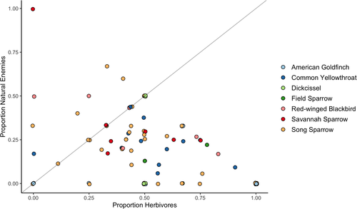

**Figure 5**

Open in figure viewer[PowerPoint](https://onlinelibrary.wiley.com/action/downloadFigures?id=ibi12994-fig-0005&doi=10.1111%2Fibi.12994)

The proportion of diet species comprising natural enemies vs. herbivores per faecal sample in the common species subset. Note that arthropods in diets were grouped by feeding guild into natural enemies, herbivores or other, although the ‘other’ category is not shown here. Therefore, the proportion of herbivores and the proportion of natural enemies within a faecal sample will not always sum to 1. Grey line is a 1 : 1 reference. Points have been jittered to show detail. *n* = 101 faecal samples. [Colour figure can be viewed at [wileyonlinelibrary.com](http://wileyonlinelibrary.com/)]

Although diet composition overlapped among both species and sites (Fig. 6), PERMANOVA tests showed significant differences among bird species and sites, as well as a significant interaction between species and site (Table 1). PERMDISP tests showed significant heterogeneity of dispersion for bird species, and for the species × site interaction, but not for site (Table 1); this indicates that these differences were at least in part due to the heterogeneity of dispersion of diets among species and species × sites (i.e. diets within species, or species × site groups, varied). *R*<sup>2</sup>-values indicated that species and species × site each explained more of the variation in diet than site alone (Table 1).

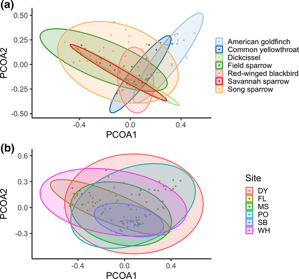

**Figure 6**

Open in figure viewer[PowerPoint](https://onlinelibrary.wiley.com/action/downloadFigures?id=ibi12994-fig-0006&doi=10.1111%2Fibi.12994)

Table 1. Results of PERMANOVA tests with 9999 permutations and PERMDISP tests on common species subset diets.

| Variable | *df* | *R* <sup>2</sup> | *P* | PERMDISP *P* |
| --- | --- | --- | --- | --- |
| Bird species | 6 | 0.14 | 0.0001 | 0.003 |
| Site | 5 | 0.06 | 0.0005 | 0.617 |
| Bird species × site | 11 | 0.11 | 0.0096 | < 0.001 |
| Residuals | 77 | 0.69 |  |  |

### American Goldfinch diets

We detected arthropod DNA in all 15 faecal samples from American Goldfinches. Goldfinch samples contained a total of 57 arthropod OTUs and a mean of 5.9 OTUs per sample (range = 2–10). Of the 57 OTUs, we identified 17 to the species level, with a mean of 1.6 OTUs per individual sample (range = 0–4). The most commonly detected OTU identified to the species level in Goldfinch diets was *Larinus planus*, which was detected in five Goldfinch faecal samples.

### Song Sparrow diets

Our most frequently sampled bird species was the Song Sparrow, which was present at all six of our study sites and provided 40 faecal samples (Fig. 2). We identified 128 arthropod species in faecal samples from Song Sparrows. Song Sparrow diet composition differed significantly between sites (*R*<sup>2</sup> = 0.163, *P* = 0.007). PERMDISP tests revealed significant heterogeneity of dispersion among sites (*P* < 0.001), which may partially reflect unbalanced sampling among sites (Appendix Table A2). Most arthropod species (100 of 128) consumed by Song Sparrows were unique to a site (Fig. 7); 12 arthropod species were detected in at least three of the six sites, and no species were detected at all six sites.

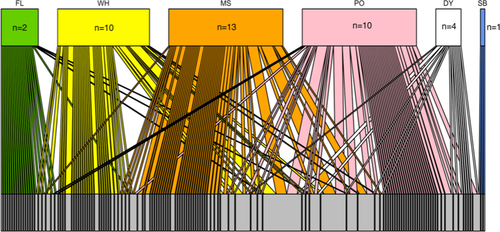

**Figure 7**

Open in figure viewer[PowerPoint](https://onlinelibrary.wiley.com/action/downloadFigures?id=ibi12994-fig-0007&doi=10.1111%2Fibi.12994)

Bipartite graph of arthropods identified to the species level detected in Song Sparrow *Melospiza melodia* diets. Each grey box at the base of the figure represents an arthropod species. Song Sparrows, represented by boxes at the top, were grouped by capture site. The width of the bar linked to the site boxes represents the number of Song Sparrows from that site which consumed the arthropod species to which the box is connected. The number of Song Sparrows sampled at each site is indicated in the top boxes. Initials above the top boxes indicate the study site as described in Appendix Table A1. [Colour figure can be viewed at [wileyonlinelibrary.com](http://wileyonlinelibrary.com/)]

## DISCUSSION

This study demonstrates the advantages of a faecal metabarcoding approach to examining diets across a bird community and across replicate sites. Our findings provide much higher resolution taxonomic data (i.e. species-level) describing bird diets in a grassland/agriculture system than have been previously described (Wiens & Rotenberry 1979). Our analysis of bird diets across multiple scales (the community, common species subset and Song Sparrows) suggests that these generalist insectivorous birds in a mixed agriculture/grassland system have surprisingly large and varied diets, with a total of 326 arthropod species detected across all samples.

Diet composition of the common species subset differed significantly among species and among replicate sites. However, differences among species were contingent upon site and, similarly, differences among sites were contingent upon species (Table 1). Song Sparrow diets varied significantly among sites, with most prey species detected at only a single site (Fig. 7). Although we do not have data describing the available arthropod communities at each site, these results are consistent with the hypothesis that the birds were exploiting food resources opportunistically based on availability. Our results are also consistent with the findings of an earlier study on grassland bird diets (Wiens & Rotenberry 1979) which showed considerable variation in diets among species and among individuals within a local population. Although stomach-sampling methods such as those used in Wiens and Rotenberry (1979) can provide information about the relative biomass of various prey items, they do not give an accurate estimation of species richness of consumed prey. Our data, on the other hand, emphasize the large species-level diversity of prey consumed by birds in our study system. Our results also show that the majority of prey items were rarely encountered in the samples: 59% of prey species were detected in only a single faecal sample. Shutt *et al*. (2020) also found most prey items to be rare in the diet of a forest-dwelling passerine during the pre-breeding season.

The ability of birds to consume a large variety of prey species, as well as the ability to exploit food resources opportunistically, has important implications for ecosystem service provision by birds. These data suggest that birds should be able to respond very quickly to pest outbreaks or increased pest densities (Whelan *et al*. 2008). In fact, the frequent consumption of the Japanese Beetle *Popillia japonica* within the bird community supports this (Fig. 4). Japanese Beetles can cause economically important damage to a variety of crops, including soybeans (Shanovich *et al*. 2019). We conducted a smaller scale faecal metabarcoding diet study in a similar agroecosystem in the year prior to this one (Garfinkel *et al*. 2020) and did not find any evidence of consumption of Japanese Beetles (although note that we used different DNA primers for the previous study, so those data are not directly comparable). As part of the annual Illinois corn and soybean survey, Japanese Beetles were found in much higher densities during the year of our present study than in the previous study (Estes 2017). The widespread consumption of Japanese Beetles we report in this study therefore probably represents opportunistic foraging on an increasingly common prey species.

While the birds in our study system show potential to respond to pest outbreaks, there is also evidence that they can provide indirect disservices by consuming arthropod natural enemies (see Garfinkel *et al*. 2020). However, the common species subset of birds consumed a significantly higher proportion of herbivorous arthropod species than natural enemy species per sample (Fig. 5). This could reflect opportunistic foraging if herbivorous species were more common than natural enemy species or, alternatively, selective foraging on the herbivore prey species. Research across a variety of ecosystems shows a consistent pattern of a higher ratio of prey to predatory species (Warren & Gaston 1992), which may indicate an opportunistic foraging strategy by birds. However, truly to disentangle opportunistic vs. selective foraging behaviours, we would need to know more about prey availability at each site. To quantify further the relative contribution of each bird to service or disservice provision, we would also need to determine the proportional contribution of each arthropod species to the overall diet (which cannot be determined with current faecal metabarcoding technology; Jedlicka *et al*. 2017). This is an important limitation of our study; as faecal metabarcoding technology advances, hopefully methodologies will be developed to overcome this limitation. Additionally, it is possible that the arthropod species included in the BOLD database library from which we identified OTUs were biased towards crop pests. Although we believe any bias was minimal because the majority of the herbivorous arthropods we identified to species were not known pests, any biases in the database could potentially affect our findings.

Two bird species from the common species subset consumed all three species of soybean pests: Song Sparrows and Red-winged Blackbirds *A. phoeniceus*. These birds may exert disproportionately large effects within our study system because they are both widespread species that can be found at higher densities than more typical grassland-dwelling bird species. Red-winged Blackbirds have historically been blamed for damage to grain crops such as rice and corn, although research suggests they probably do not decrease crop yield as much as farmers perceive them to (Weatherhead *et al*. 1982, Borkhataria *et al*. 2012). Our findings, based on the faecal metabarcoding technique, suggest, in fact, that Red-winged Blackbirds, along with Song Sparrows, may provide an important but overlooked service within this study system. It is important to note, however, that other bird species may also provide disproportionate services in this system that were undetected due to small sample sizes.

Another bird species of interest in our common species subset is the American Goldfinch. Previous observational and stomach sampling studies have shown that although American Goldfinches may eat a few insects such as aphids when encountered, insects constitute a small proportion of their diet (Coutlee 1963, McGraw & Middleton 2020). Because they were common at our study sites, however, we included them in the metabarcoding analyses to provide a comparison with the more insectivorous species. Surprisingly, we detected arthropod DNA in all 15 faecal samples from goldfinches. This finding may reflect the inability of the DNA metabarcoding approach to distinguish between arthropod life stages. Arthropods consumed as adults, larvae or eggs will all appear identically in the diet composition data. It is possible, therefore, that the Goldfinches consumed nymphs, larvae or eggs inadvertently while foraging for seeds. In particular, the most commonly detected arthropod in the Goldfinch samples was *Larinus planus*, a species of weevil that lays its eggs in thistle heads (Havens *et al*. 2012). As thistle seeds are a preferred food of American Goldfinches (McGraw & Middleton 2020), foraging for seeds in thistle seedheads could lead to unintended weevil consumption by Goldfinches.

On the other hand, our results suggest that Goldfinches may also intentionally consume arthropods more commonly than previously assumed. Indeed, the PCoA analysis shows that although the American Goldfinch diet is somewhat distinct from the more insectivorous species, there are nonetheless considerable overlaps with the other species (Fig. 6a). In fact, we found that Goldfinches consumed a higher proportion of herbivorous species compared with Song Sparrows, and we detected DNA from two soybean pests in Goldfinch diets (*C*. *setatrius* and *P*. *japonica*). Even if Goldfinches consumed only pest arthropod eggs or larvae, this represents a previously undescribed contribution to pest control by a largely granivorous species. We recommend further examination of this phenomenon to confirm whether Goldfinches are indeed consuming eggs or larvae rather than adult pests. If this is the case, it would be important to determine whether they consume them in high enough quantities to affect pest populations substantially.

## CONCLUSIONS

The use of faecal metabarcoding to identify species-level diet components of a bird community provided unique insight into the diets of bird communities in a mixed agricultural/grassland system. First, we show that these bird species collectively have an extremely varied diet, and may respond opportunistically to prey availability. This supports the hypothesis that birds can contribute to agricultural resiliency against pest outbreaks. Secondly, we show that the bird community consumed more species of herbivorous arthropods than natural enemies. In addition, three of the nine most commonly consumed arthropod species we detected were known pests of soybeans. When herbivore density is high enough to decrease crop yield, birds may provide net services, although when herbivore biomass is low compared with natural enemies, we may see net disservices by birds. Finally, we identified two bird species, Red-winged Blackbird and Song Sparrow, that are both common and that consumed all three soybean pest species, and a third common species, the American Goldfinch, which potentially contributes to arthropod pest control despite its classification as a nearly obligate granivore. Future research should further examine the ability of these bird species to contribute to pest-removal services in soybean agriculture. Together, these results enhance our current knowledge of trophic effects exerted by bird communities that may have economic consequences in agriculture.

We thank the farmers who allowed us to capture birds in their fields, as well as the staff of Kane and DeKalb Forest Preserve Districts, and of Nachusa Grasslands. We thank Daryl Coldren, Veronika Shumeyko and Joanna Lopez for their help with mist-netting. We are especially thankful to Dr Wesley Swingley of Northern Illinois University, who provided lab space, and instruction and advice to M.G. for DNA extractions. We also thank three anonymous reviewers and editors Rebecca Kimball and Frank Rheindt whose comments helped improve the manuscript. Funding was provided to M.G. by Friends of Nachusa Grasslands and UIC’s Elmer Hadley Graduate Research Award. This study was conducted with the approval of UIC’s Institutional Animal Care and Use Committee (ACC protocol 16-043). DNA sequencing was performed by the UIC Research Informatics Core, supported in part by NCATS through Grant UL1TR002003.

## Author Contributions

**Megan Garfinkel:** Conceptualization (equal); Formal analysis (lead); Funding acquisition (lead); Investigation (lead); Methodology (equal); Writing-original draft (lead); Writing-review & editing (lead). **Emily Minor:** Conceptualization (supporting); Formal analysis (supporting); Funding acquisition (supporting); Methodology (supporting); Supervision (equal); Writing-review & editing (equal). **Christopher J. Whelan:** Conceptualization (equal); Formal analysis (supporting); Funding acquisition (supporting); Supervision (equal); Writing-review & editing (equal).

## PCR conditions and technical sequencing methods

We used a forward primer with the sequence: ACACTGACGACATGGTTCTACA GGTCAACAAATCATAAAGATATTGG (linker portion is underlined) and a reverse primer with the sequence TACGGTAGCAGAGACTTGGTCTGGWACTAATCAATTTCCAAATCC (Jusino 2019). First-stage PCR amplifications were performed in 10 -µL reactions in 96-well plates, using MyTaq HS 2× Mastermix (Bioline). PCR conditions were five cycles of: 95 °C for 60 s, 45 °C for 90 s, 72 °C for 90 s; 28 cycles of: 94 °C for 60 s, 50 °C for 90 s, 72 °C for 60 s. Subsequently, a second PCR amplification was performed in 10 -µL reactions in 96-well plates. A mastermix for the entire plate was made with MyTaq HS 2× Mastermix. Each well received a separate primer pair with a unique 10-base barcode, which was obtained from the Access Array Barcode Library for Illumina (Fluidigm, South San Francisco, CA, USA; Item# 100-4876). These primers contained the CS1 and CS2 linkers at the 3' ends of the oligonucleotides. Cycling conditions were: 95 °C for 5 min, followed by eight cycles of 95 °C for 30 s, 60 °C for 30 s and 72 °C for 30 s. Samples were subsequently pooled in equal volume using an EpMotion5075 liquid handling robot (Eppendorf, Hamburg, Germany). The pooled library was purified to remove fragments smaller than 200 bp using an AMPure XP cleanup protocol (1×, v/v; Agencourt, Beckmann-Coulter). The pooled libraries, with a 20% phiX spike-in, were loaded onto an Illumina MiniSeq mid-output flow cell (2 × 153 paired-end reads). The amplicons (before purification) were-pooled based on the distribution of reads per barcode, to generate a more balanced distribution of reads. The re-pooled library was purified using AMPure XP cleanup, as described above. The re-pooled libraries, with a 20% phiX spike-in, were loaded onto a MiniSeq flow cell, and sequenced (2 × 153 paired-end reads). Fluidigm sequencing primers (targeting the CS1 and CS2 linker regions) were used to initiate sequencing. De-multiplexing of reads was then performed.

**Table A1** Approximate area in hectares of the soybean field and grassland patches at six study sites, Illinois, USA.

| Site<sup>a</sup> | Ownership of grassland | Area grassland (ha) | Area soybeans (ha) |
| --- | --- | --- | --- |
| DY | Kane County Forest Preserve District | 240 | 4 |
| PO | Dekalb Country Forest Preserve District | 11 | 83 |
| MS | Kane Country Forest Preserve District | 175 | 35 |
| FL | The Nature Conservancy | 94 | 10 |
| SB | The Nature Conservancy | 45 | 27 |
| WH | The Nature Conservancy | 94 | 44 |

- <sup>a</sup> DY = Dick Young Forest Preserve; PO = Prairie Oaks Forest Preserve; MS = Muirhead Springs Forest Preserve; FL = Nachusa Grasslands at Flagg and Lowden roads; SB = Nachusa Grasslands at Stone Barn Road; WH = Nachusa Grasslands at White House.

| Common name | Scientific name | Code | DY | FL | MS | PO | SB | WH |
| --- | --- | --- | --- | --- | --- | --- | --- | --- |
| American Goldfinch | *Spinus tristis* | AMGO | 2 |  | 2 | 4 | 4 | 3 |
| American Robin | *Turdus migratorius* | AMRO |  | 2 |  | 1 |  | 1 |
| Baltimore Oriole | *Icterus galbula* | BAOR |  |  |  | 1 |  |  |
| Barn Swallow | *Hirundo rustica* | BARS |  |  | 1 | 1 |  | 1 |
| Black-capped Chickadee | *Poecile atricapillus* | BCCH |  |  |  |  |  | 1 |
| Bobolink | *Dolichonyx oryzivorus* | BOBO |  |  | 3 |  |  |  |
| Brown Thrasher | *Toxostoma rufum* | BRTH |  |  |  | 1 |  |  |
| Cedar Waxwing | *Bombycilla cedrorum* | CEDW |  | 1 |  |  |  |  |
| Chipping Sparrow | *Spizella passerina* | CHSP |  |  |  |  |  | 1 |
| Common Yellowthroat | *Geothlypis trichas* | COYE | 4 | 2 | 4 | 7 |  |  |
| Dickcissel | *Spiza americana* | DICK |  |  | 1 |  | 4 | 1 |
| Eastern Meadowlark | *Sturnella magna* | EAME |  | 2 |  |  |  |  |
| Eastern Phoebe | *Sayornis phoebe* | EAPH | 2 |  |  |  |  | 1 |
| Field Sparrow | *Spizella pusilla* | FISP |  | 6 |  |  |  |  |
| Grasshopper Sparrow | *Ammodramus savannarum* | GRSP |  | 1 |  |  |  |  |
| Henslow’s Sparrow | *Ammodramus henslowii* | HESP | 1 |  |  |  |  |  |
| House Wren | *Troglodytes aedon* | HOWR |  | 1 |  |  |  |  |
| Indigo Bunting | *Passerina cyanea* | INBU |  |  |  | 1 | 1 |  |
| Orchard Oriole | *Icterus spurius* | OROR |  |  |  | 1 |  |  |
| Red-winged Blackbird | *Agelaius phoeniceus* | RWBL |  |  | 2 | 5 |  |  |
| Savannah Sparrow | *Passerculus sandwichensis* | SAVS |  |  | 4 |  | 6 |  |
| Sedge Wren | *Cistothorus platensis* | SEWR | 1 |  |  |  |  |  |
| Song Sparrow | *Melospiza melodia* | SOSP | 4 | 2 | 13 | 10 | 1 | 10 |
| Vesper Sparrow | *Pooecetes gramineus* | VESP |  |  |  |  |  | 2 |
| Willow Flycatcher | *Empidonax traillii* | WIFL |  |  |  | 2 |  |  |

## Citing Literature

[figure not shown]

[Volume164, Issue1](https://onlinelibrary.wiley.com/toc/1474919x/2022/164/1)

January 2022

Pages 27-43

### Recommended

  [Gen-Chang Hsu](https://onlinelibrary.wiley.com/action/doSearch?ContribAuthorRaw=Hsu%2C+Gen-Chang), [Jia-Ang Ou](https://onlinelibrary.wiley.com/action/doSearch?ContribAuthorRaw=Ou%2C+Jia-Ang), [Chuan-Kai Ho](https://onlinelibrary.wiley.com/action/doSearch?ContribAuthorRaw=Ho%2C+Chuan-Kai),

  [BRIAN N. HOGG](https://onlinelibrary.wiley.com/action/doSearch?ContribAuthorRaw=HOGG%2C+BRIAN+N), [KENT M. DAANE](https://onlinelibrary.wiley.com/action/doSearch?ContribAuthorRaw=DAANE%2C+KENT+M),

  [David H. Wise](https://onlinelibrary.wiley.com/action/doSearch?ContribAuthorRaw=Wise%2C+David+H), [Denise M. Moldenhauer](https://onlinelibrary.wiley.com/action/doSearch?ContribAuthorRaw=Moldenhauer%2C+Denise+M), [Juraj Halaj](https://onlinelibrary.wiley.com/action/doSearch?ContribAuthorRaw=Halaj%2C+Juraj),

  [Lucy J. Mitchell](https://onlinelibrary.wiley.com/action/doSearch?ContribAuthorRaw=Mitchell%2C+Lucy+J), [Gavin J. Horsburgh](https://onlinelibrary.wiley.com/action/doSearch?ContribAuthorRaw=Horsburgh%2C+Gavin+J), [Deborah A. Dawson](https://onlinelibrary.wiley.com/action/doSearch?ContribAuthorRaw=Dawson%2C+Deborah+A), [Kathryn H. Maher](https://onlinelibrary.wiley.com/action/doSearch?ContribAuthorRaw=Maher%2C+Kathryn+H), [Kathryn E. Arnold](https://onlinelibrary.wiley.com/action/doSearch?ContribAuthorRaw=Arnold%2C+Kathryn+E),

  [Cody M. Kent](https://onlinelibrary.wiley.com/action/doSearch?ContribAuthorRaw=Kent%2C+Cody+M), [Kyu Min Huh](https://onlinelibrary.wiley.com/action/doSearch?ContribAuthorRaw=Huh%2C+Kyu+Min), [Sarah Chieko Hunter](https://onlinelibrary.wiley.com/action/doSearch?ContribAuthorRaw=Hunter%2C+Sarah+Chieko), [Kathryn Judson](https://onlinelibrary.wiley.com/action/doSearch?ContribAuthorRaw=Judson%2C+Kathryn), [Luke L. Powell](https://onlinelibrary.wiley.com/action/doSearch?ContribAuthorRaw=Powell%2C+Luke+L), [Thomas W. Sherry](https://onlinelibrary.wiley.com/action/doSearch?ContribAuthorRaw=Sherry%2C+Thomas+W),

  [Ibis](https://onlinelibrary.wiley.com/journal/1474919x)

[Download PDF](https://onlinelibrary.wiley.com/doi/pdf/10.1111/ibi.12994)

[figure not shown]